# Partie 2 sur R

Clovis Deletre

Charles Vitry

# Introduction

Import des deux jeux de données | format csv

```r
train <-
  read.csv(file = "churner_train_data_set.csv", header = TRUE, sep = ",")
#head(train)

test <- read.csv(file = "churner_test_data_set.csv", header = TRUE, sep =
                   ",")
#head(test)
```

Création variables

```r
train$groupe <- ifelse(train$churner == 1 , TRUE, FALSE)
test$groupe <- ifelse(test$churner == 1 , TRUE, FALSE)
```

# ACP sur Jeu d’entrainement

scale.unit: pour choisir de réduire ou non les variables ncp: le nombre de dimensions à garder dans les résultats graph: pour choisir de faire apparaître les graphiques ou non

```r
library(FactoMineR)
library("factoextra")
```

```r
#Test d'une ACP en prenant churner en variable qualitative
res.pca = PCA(
  train[, 2:133],
  scale.unit = TRUE,
  quali.sup = 132 ,
  ncp = 131,
  graph = T
)
```

## Création de l’ACP

```r
library(FactoMineR)
library("factoextra")

#ACP en excluant la collone d'identification de l'individu ainsi que la variable à expliquée.
#res.pca = PCA(train[,2:132], scale.unit=TRUE, ncp=131, graph=T)


#mauvaise méthode, faire l'ACP sur les données à tester n'a aucun sens,
#en effet, pour estimer le prix d'un contrat, on ne peut pas attendre que 5000 clients attendent l'estimation de leur contrat
#il faut projeter les nouvelles données avec l'ACP effectué sur le jeu d'entrainement.
#res.pca.test = PCA(test[,2:132], scale.unit=TRUE, ncp=131, graph=T)


library(ade4)
res.pca <- dudi.pca(train[,2:132],
                    scannf = FALSE,   # Cacher le scree plot
                    nf = 131            # Nombre d'axes gardés
                    )
```

## Visualisation

Affichage des individus

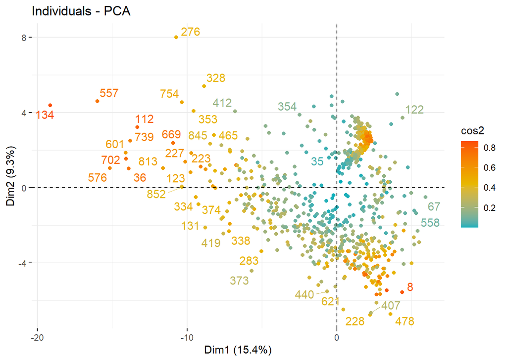

```r
#plot.PCA(res.pca, axes=c(1, 2), choix="ind", habillage=5,label="var",graph.type = "ggplot")
fviz_pca_ind(res.pca,
             col.ind = "cos2",
             gradient.cols = c("#00AFBB", "#E7B800", "#FC4E07"),
             repel = TRUE
             )
```

## Sélection du nombre d’axes

Observons l’inertie expliqué

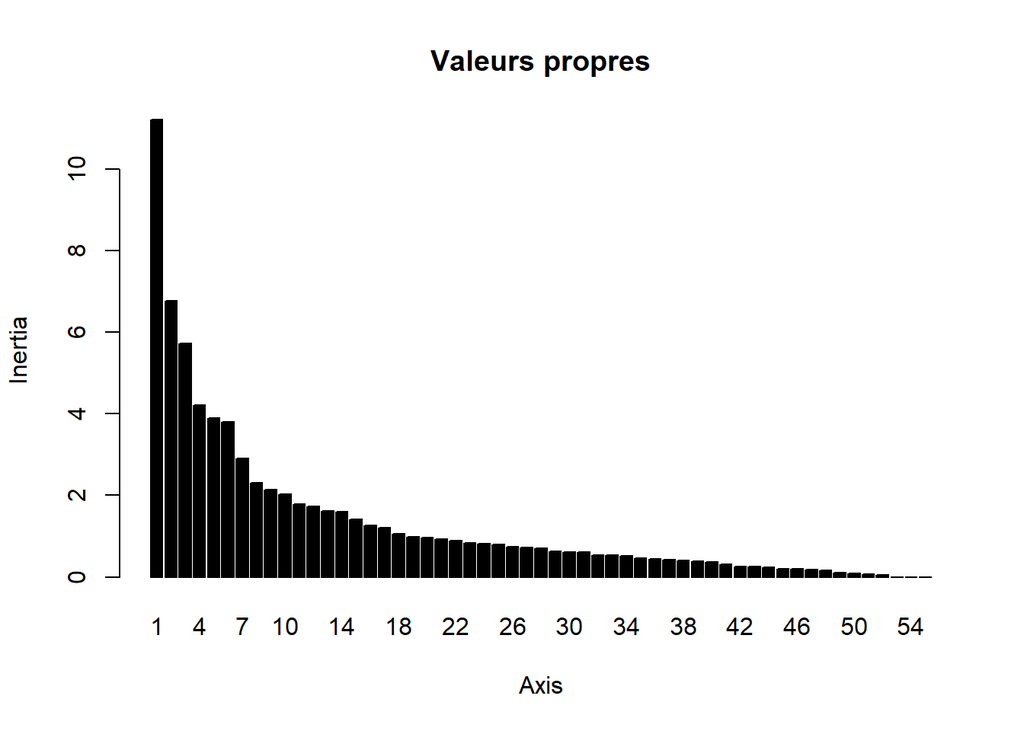

```r
#head(res.pca$eig)
screeplot(res.pca, main = "Valeurs propres")
```

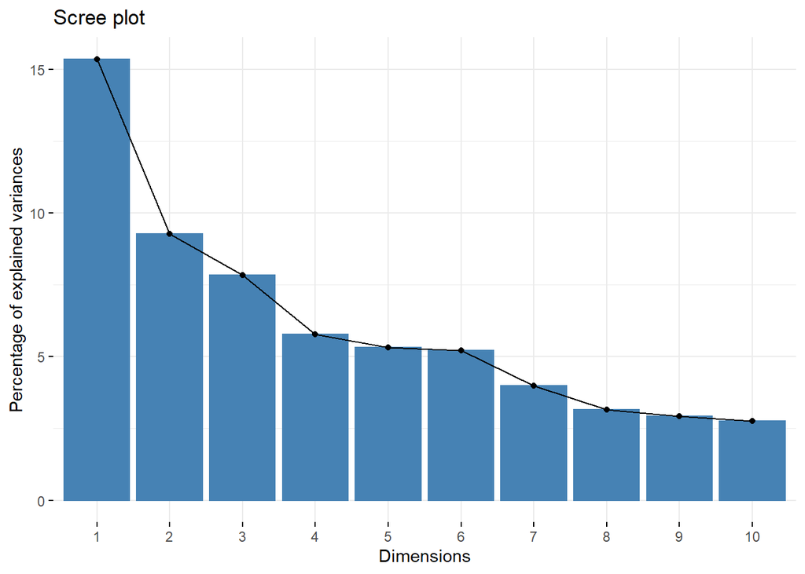

```r
fviz_eig(res.pca)
```

```r
library(factoextra)
# Valeurs propres
vp <- get_eigenvalue(res.pca)
head(vp)
```

```
##       eigenvalue variance.percent cumulative.variance.percent
## Dim.1  11.211388        15.358066                    15.35807
## Dim.2   6.772053         9.276785                    24.63485
## Dim.3   5.719295         7.834650                    32.46950
## Dim.4   4.210334         5.767581                    38.23708
## Dim.5   3.889635         5.328268                    43.56535
## Dim.6   3.807823         5.216196                    48.78155
```

On utilise les valeurs propres pour déterminer le nombre p’ d’axes principaux à conserver après l’ACP avec la règle de Kaiser (1961)

- On prend les valeurs propre > 1, impliquant que la composante va représenté plus de variance par rapport à une seule variable d’origine
- On prend un ensemble de valeurs propres qui ont une variance cumulée d’au moins 70% (explique au moins 70% de l’inertie)

Ici on prend les 24 premières compostantes pour former nos 24 axes principaux

````r
# #res.pca$ind$coord
#
# #Variables
# res.var <- get_pca_var(res.pca)
#
# # Coordonnées
# #head(res.var$coord  )
#
# # Contributions aux axes
# #head(res.var$contrib   )
#
# # Qualité de représentation
# head(res.var$cos2  )
#
# #Isndividus
# res.ind <- get_pca_ind(res.pca)
#
# # Coordonnées
# #head(res.ind$coord )
#
# # Contributions aux axes
# #head(res.ind$contrib )
#
# # Qualité de représentation
# head(res.ind$cos2  )
# ```
````

## Qualité

qualité de répresentation

```r
sujetVar <- get_pca_var(res.pca)

head(sujetVar$cos2)
```

[output not shown]

Qualité par axes coloré

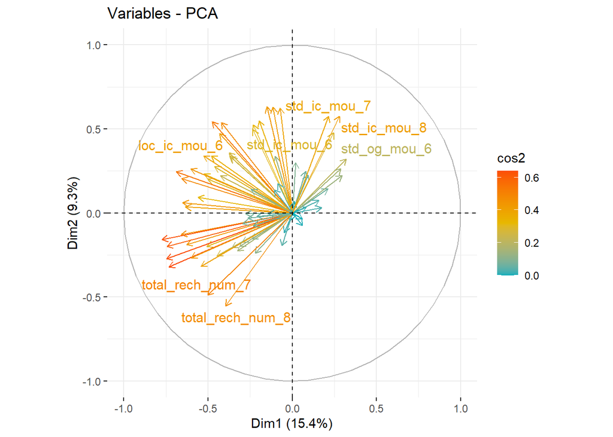

```r
fviz_pca_var(
  res.pca,
  col.var = "cos2",
  gradient.cols = c("#00AFBB", "#E7B800", "#FC4E07"),
  repel = TRUE
)
```

Top 5 des variables explicatives du premier axe

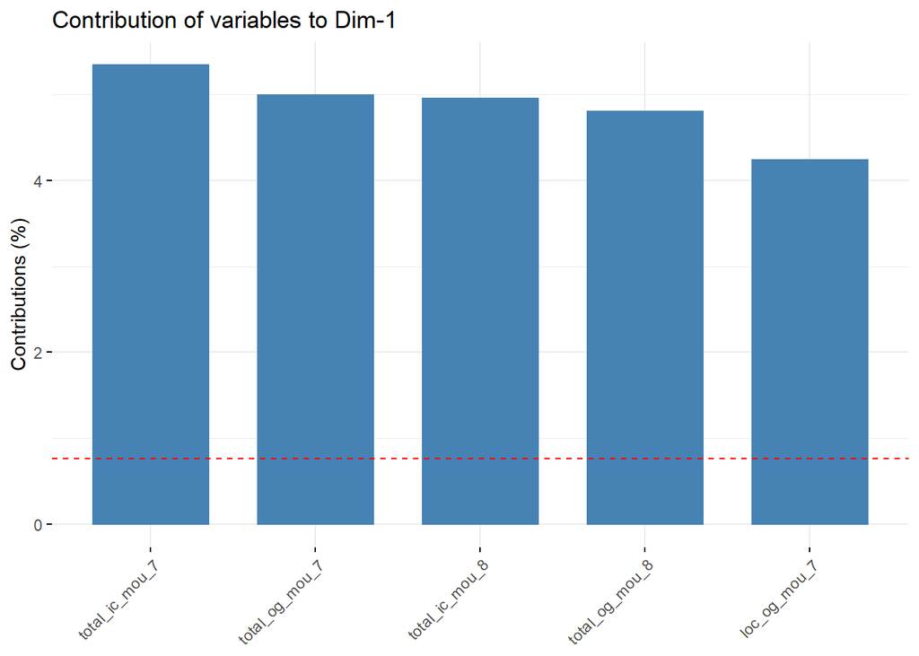

```r
#
fviz_contrib(res.pca,
             choice = "var",
             axes = 1,
             top = 5)
```

Tracage d’ellypse de confiance

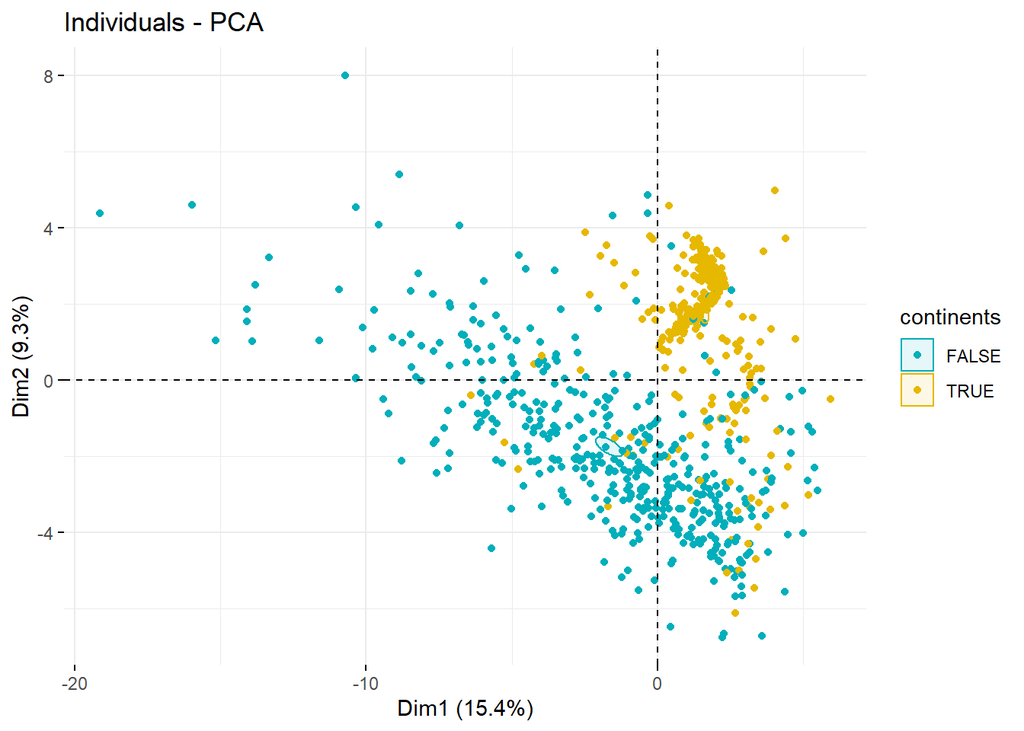

```r
fviz_pca_ind(
  res.pca,
  geom.ind = "point",
  col.ind = train$groupe,
  palette = c("#00AFBB", "#E7B800", "#FC4E07", "#9bcd9b"),
  addEllipses = TRUE,
  ellipse.type = "confidence",
  legend.title = "continents"
)
```

# ACP sur jeu de test

On projette les données du jeu test avec l’ACP effectué sur le jeu d’entrainement.

```r
library(ade4)
ACPsurTest <- suprow(res.pca, test[,2:132])$lisup
```

Visualisation projection des nouveaux individus

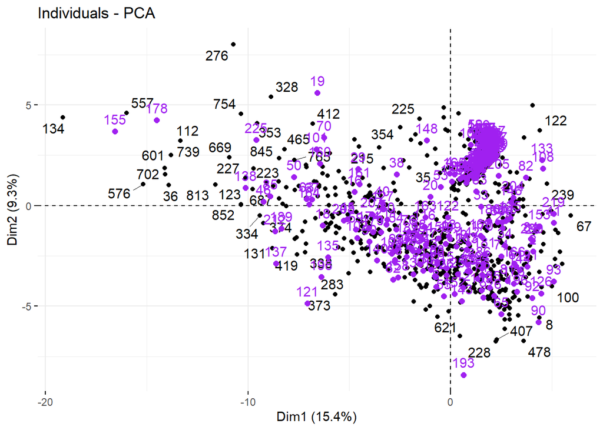

```r
#plot des obs train
plot <- fviz_pca_ind(res.pca, repel = TRUE)

#plot des obs de test
fviz_add(plot, ACPsurTest, color ="purple")
```

```r
trainACP <- as.data.frame(
 # res.pca$ind$coord[, 1:24]
  res.pca$li[, 1:24]
  )
testACP <- ACPsurTest[, 1:24]



y = train[, 134]
y.test = test[, 134]


trainACP <- cbind(trainACP, y)
testACP <- cbind(testACP, y.test)
```

# SVM

## Introduction

SVM utilisé en tant que classifieur permet de trouver un ligne (R²), un plan (R^3), un hyperplan (R^n) qui sépare les observations en classes.

Dans le cas du SVM linaéaire binaire on séparer linéairement une Classe +1 et une Classe -1, Une infinité de solutions est possible pour ces problèmes,on cherche la solution qui maximise la marge et minimise les erreurs.

Cependant lors de la recherche des points supports, les outliers(valeurs abérantes) vont faire perdre toute généralisation au modèle, pour contrer cela on accepte alors des erreurs, on change de classe les outliers.

## Création SVM

Fonction création d’un SVM

```r
svm_para <- function(type , kernel)
{
  library(e1071)

  svmfit <- tune.svm(
    x = trainACP[,-25],
    y = trainACP[, 25],
    type = type,
    kernel = kernel,
    cost = 1:10,
    #on peut faire bien plus
    gamma = seq(0, 0.5, by = 0.1),
    tunecontrol = tune.control(cross = 8)
  )
  return (svmfit)
}
```

les paramètres différentiant les SVM : le type de classifieur & la fonction kernel utilisé.

## Critères de comparaison des SVM

Fonction d’évaluation d’un SVM

```r
Performances_SVM <- function(svmfit,type,kernel)
{
  library(caret)
  Resultat <- list(7)
  Resultat[1] <- type
  Resultat[2] <- kernel
  Resultat[3] <- svmfit$best.parameters$cost
  Resultat[4] <- svmfit$best.parameters$gamma

  #Prédictions
  SVM_pred_training = predict(svmfit$best.model, newdata  = trainACP[,-25])
  SVM_pred_testing = predict(svmfit$best.model, newdata  = testACP[,-25] )

  #Matrices de confusion train et test
  MatriceConfu_SVM_train <-
    confusionMatrix(table (SVM_pred_training, trainACP[, 25]))
  MatriceConfu_SVM_test <-
    confusionMatrix(table (SVM_pred_testing, testACP[, 25]))

  #retour de résultat des matrices de confusions
  Resultat[5:6] <- MatriceConfu_SVM_train$overall[1:2]
  Resultat[7:9] <- MatriceConfu_SVM_train$byClass[c("Sensitivity","Specificity","Balanced Accuracy")]

  Resultat[10:11] <- MatriceConfu_SVM_test$overall[1:2]
  Resultat[12:14] <-MatriceConfu_SVM_test$byClass[c("Sensitivity","Specificity","Balanced Accuracy")]

  Resultat[15] <- svmfit$best.model$tot.nSV

  return (Resultat)
}
```

On créé une liste contenant les différentes mesures de performances pour le jeu d’entrainement Et le jeu de test.

http://john-uebersax.com/stat/kappa.htm

Création d’un tableau pour afficher les performances des différents SVM selon les paramètres

```r
N <- 8  # nombre de lignes

Tableau_Resultat_SVM <- data.frame(
  type = rep("", N),
  kernel = rep("", N),
  BestCost = rep(NA, N),
  BestGamma = rep(NA, N),

  Accuracy_Training = rep(NA, N),
  Kappa__Training = rep(NA, N),
  Sensitivity_Training = rep(NA, N),
  Specificity_Training = rep(NA, N),
  Balanced_Accuracy_Training = rep(NA, N),

  Accuracy_Testing = rep(NA, N),
  Kappa__Testing = rep(NA, N),
  Sensitivity_Testing = rep(NA, N),
  Specificity_Testing = rep(NA, N),
  Balanced_Accuracy_Testing = rep(NA, N),


  Nombre_De_Vecteur_Support = rep(NA, N),
  stringsAsFactors = FALSE
)


#svmfit_normal   = svm(formula = y~.,
#                data = trainACP,
#              type = 'C-classification',
#          kernel = 'linear')
```

## Comparaison des SVM

On créé deux vecteurs, l’un contenant tout les types de classifieur & l’autre contenant les fonctions kernel possible.

On test toute les combinaisons possibles en appelant notre fonction de création de SVM, puis on évalue le modèle avec la fonction d’évaluation de SVM. On sauvegarde ces performances dans le tableau, et si le modèle a une meilleure Balanced Accuracy que le meilleur actuel, on affecte ce modèle au meilleur.

```r
#type
type_liste <- c("C-classification",
                "nu-classification",
                "one-classification"
                #      "eps-regression",
                #     "nu-regression"
                )

#kernel
kernel_liste <-
  c("linear", "polynomial", "radial", "sigmoid")


#variables
i = 1
meilleur_Accuracy = 0


#boucles
for (x in seq_along(type_liste)) {
  for (y in seq_along(kernel_liste)) {
    print("----------------")
    print(type_liste[x])
    print(kernel_liste[y])

    #nu classification uniquement compatible avec un kernel linéaire
    if (!(x == 2 && y != 1)) {
      #one classification pas compatible avec kernel polynomial
      if (!(x == 3 && y == 2)) {


        #On test toute les combinaisons possibles en appelant notre fonction de création de SVM
        svm_test <- svm_para(type_liste[x], kernel_liste[y])

        #On sauvegarde ces performances dans le tableau
        Tableau_Resultat_SVM[i, ] <-
          Performances_SVM(svm_test, type_liste[x], kernel_liste[y])

        #si le modèle a une meilleure Balanced Accuracy que le meilleur actuel, on affecte ce modèle au meilleur.
       if( Tableau_Resultat_SVM[i,14 ] > meilleur_Accuracy){
         meilleur_svm <- svm_test
         meilleur_Accuracy <- Tableau_Resultat_SVM[i,14 ]
       }


        i <- i + 1
      }
    }

  }
}
```

```
## [1] "----------------"
## [1] "C-classification"
## [1] "linear"
```

```
## [1] "----------------"
## [1] "C-classification"
## [1] "polynomial"
## [1] "----------------"
## [1] "C-classification"
## [1] "radial"
## [1] "----------------"
## [1] "C-classification"
## [1] "sigmoid"
## [1] "----------------"
## [1] "nu-classification"
## [1] "linear"
## [1] "----------------"
## [1] "nu-classification"
## [1] "polynomial"
```

[output cut: 18 more lines]

On obtient alors un tableau avec les performances de chaque modèle et le modèle ayant la Balanced Accuracy la plus haute.

```r
#performance des modèles
Tableau_Resultat_SVM
```

```
##                 type     kernel BestCost BestGamma Accuracy_Training
## 1   C-classification     linear        2       0.0         0.9587514
## 2   C-classification polynomial        2       0.1         0.9933110
## 3   C-classification     radial        2       0.1         0.9910814
## 4   C-classification    sigmoid        6       0.1         0.8149387
## 5  nu-classification     linear        1       0.0         0.9431438
## 6 one-classification     linear        1       0.0         0.1170569
## 7 one-classification     radial        1       0.3         0.7692308
## 8 one-classification    sigmoid        1       0.3         0.5362319
##   Kappa__Training Sensitivity_Training Specificity_Training
## 1      0.91754675            0.9864560            0.9317181
## 2      0.98662079            0.9954853            0.9911894
## 3      0.98216203            0.9954853            0.9867841
## 4      0.62978120            0.8081264            0.8215859
## 5      0.88640410            0.9909707            0.8964758
```

[output cut: 30 more lines]

```r
#library(tidyverse)
# result1  <- bind_cols(Tableau_Resultat_SVM[,1:2] , Tableau_Resultat_SVM[,3:4], Tableau_Resultat_SVM[,15])
# result2  <- bind_cols(Tableau_Resultat_SVM[,1:2] , Tableau_Resultat_SVM[,5:9])
# result3  <- bind_cols(Tableau_Resultat_SVM[,1:2] , Tableau_Resultat_SVM[,10:14])
#
# result1
# result2
# result3

#meilleur modèle
#meilleur_svm
```